# Poster project

Christoffer Mondrup Kramer

2023-05-24

# Poster project

I will do a toy example of my poster project.

# Step 1: Describe data

What kind of data are we dealing with? What are categorical, what is numerical, what are the attributes, what do we want to classify?

```r
full_df <- read.table("T11-9.dat")
full_df$V8 <- as.numeric(as.character(full_df$V8))
full_df
```

```
##                         V1 V2  V3 V4 V5  V6  V7   V8 V9 V10 V11
## 1               ACCheerios  G 110  2  2 180 1.5 10.5 10  70   1
## 2                 Cheerios  G 110  6  2 290 2.0 17.0  1 105   1
## 3               CocoaPuffs  G 110  1  1 180 0.0 12.0 13  55   1
## 4             CountChocula  G 110  1  1 180 0.0 12.0 13  65   1
## 5            GoldenGrahams  G 110  1  1 280 0.0 15.0  9  45   1
## 6         HoneyNutCheerios  G 110  3  1 250 1.5 11.5 10  90   1
## 7                      Kix  G 110  2  1 260 0.0 21.0  3  40   1
## 8              LuckyCharms  G 110  2  1 180 0.0 12.0 12  55   1
## 9       MultiGrainCheerios  G 100  2  1 220 2.0 15.0  6  90   1
## 10      OatmealRaisinCrisp  G 130  3  2 170 1.5 13.5 10 120   1
## 11           RaisinNutBran  G 100  3  2 140 2.5   NA  8 140   1
## 12         TotalCornFlakes  G 110  2  1 200 0.0 21.0  3  35   1
## 13         TotalRaisinBran  G 140  3  1 190 4.0 15.0 14 230   1
## 14         TotalWholeGrain  G 100  3  1 200 3.0 16.0  3 110   1
```

[output cut: 29 more lines]

The dataset contains the following information:  
- V1: Cereal brand  
- Type: string  
- V2: Manufacturer  
- Type: Categorical String  
- V3: Calories  
- Type: Numerical  
- V4: Protein  
- Type: Numerical  
- V5: Fat  
- Type: Numerical  
- V6: Sodium  
- Type: Numerical  
- V7: Fiber  
- Type: Numerical  
- V8: Carbohydrates  
- Type: Numerical  
- V9: Sugar  
- Type: Numerical  
- V10: Potasium  
- Type: Numerical  
- V11: Group  
- Type: Numerical categorical

The first step will be to remove V1, V2, and V11, since V2 is not interesting for our purposes, and V1 or V2 will be our classification variable (here it will probably be V11). Moreover V8 needs to be converted to numerical

```r
df <- full_df[, -c(1, 2, 11)]
df$V8 <- as.numeric(as.character(df$V8))
df <- df[-11,] # contains NA
df
```

```
##     V3 V4 V5  V6  V7   V8 V9 V10
## 1  110  2  2 180 1.5 10.5 10  70
## 2  110  6  2 290 2.0 17.0  1 105
## 3  110  1  1 180 0.0 12.0 13  55
## 4  110  1  1 180 0.0 12.0 13  65
## 5  110  1  1 280 0.0 15.0  9  45
## 6  110  3  1 250 1.5 11.5 10  90
## 7  110  2  1 260 0.0 21.0  3  40
## 8  110  2  1 180 0.0 12.0 12  55
## 9  100  2  1 220 2.0 15.0  6  90
## 10 130  3  2 170 1.5 13.5 10 120
## 12 110  2  1 200 0.0 21.0  3  35
## 13 140  3  1 190 4.0 15.0 14 230
## 14 100  3  1 200 3.0 16.0  3 110
## 15 110  1  1 140 0.0 13.0 12  25
```

[output cut: 28 more lines]

# Step 2: Descriptive statistics

## Scatter plot

Before we start with anything let us make a scatterplot of the pairs:

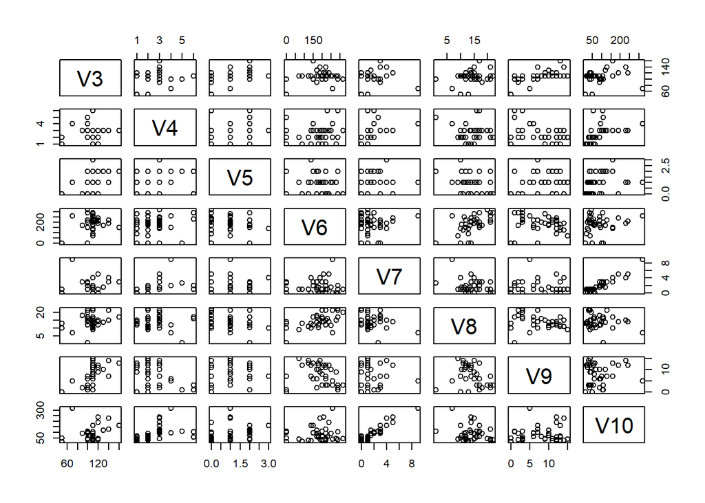

```r
pairs(df)
```

As the scatterplot above shows, V4 and V5 looks a lot like categorical variables, they might need to be excluded:

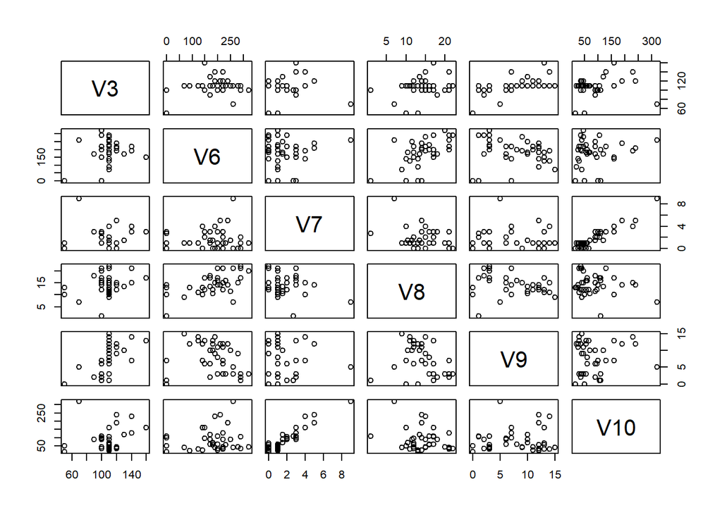

```r
df <- df[, -c(2, 3)]
pairs(df)
```

At a quick glance some of the variables might be correlated:  
- V7 and V10  
- v6 and V8  
- V6 and V9  
- V3 and V10

## Mean, variance, co-variance

Let us get some simple stats:

```r
#mean(full_df)
colMeans(df)
```

```
##         V3         V6         V7         V8         V9        V10
## 108.095238 181.428571   1.695238  14.345238   7.595238  83.095238
```

```r
cov(df)
```

```
##              V3         V6          V7         V8          V9        V10
## V3  367.0150987  510.10453  -0.5214866  20.429733  51.1614402  192.62485
## V6  510.1045296 6386.93380   7.1289199 192.177700 -17.5783972  669.86063
## V7   -0.5214866    7.12892   3.3009524  -1.815389  -0.2946574  112.08827
## V8   20.4297329  192.17770  -1.8153891  18.213269  -6.1983159  -59.14344
## V9   51.1614402  -17.57840  -0.2946574  -6.198316  21.0760743   24.45412
## V10 192.6248548  669.86063 112.0882695 -59.143438  24.4541231 4399.94193
```

let us also check the generalized variance:

```r
sum(diag(cov(df)))
```

```
## [1] 11196.48
```

This is pretty high, but not something that is unexpected given, that some variabels have a high variance.

Okay, we can now conclude that no variable appears to be completed unrelated, since none are 0. Moreover, V10, V6 have a very high variance, but a low mean, which might indicate, that there are some crazy outliers, the same goes for V3 and V9 to a lesser extend. Let’s check them:

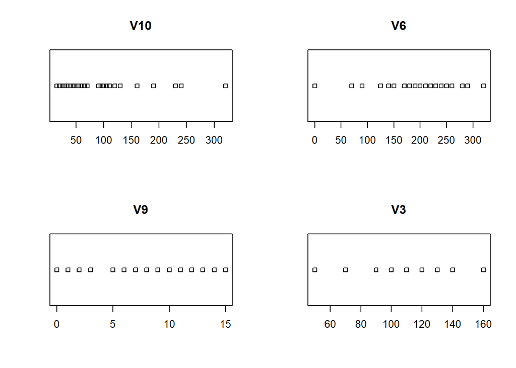

```r
par(mfrow = c(2, 2))
stripchart(df$V10, main = "V10")
stripchart(df$V6, main = "V6")
stripchart(df$V9, main = "V9")
stripchart(df$V3, main = "V3")
```

Yep we need to keep an eye out for V10’s outliers, V6 is not that bad, but still has an outlier. V3 and V9 looks good however.

Now let’s check there correlation and let us keep an eye out on those we saw at the scatter plot:

```r
cor(df)
```

```
##              V3          V6          V7         V8          V9         V10
## V3   1.00000000  0.33317393 -0.01498241  0.2498773  0.58170920  0.15158174
## V6   0.33317393  1.00000000  0.04909733  0.5634597 -0.04791133  0.12636150
## V7  -0.01498241  0.04909733  1.00000000 -0.2341295 -0.03532668  0.93007305
## V8   0.24987728  0.56345966 -0.23412950  1.0000000 -0.31636242 -0.20892439
## V9   0.58170920 -0.04791133 -0.03532668 -0.3163624  1.00000000  0.08030337
## V10  0.15158174  0.12636150  0.93007305 -0.2089244  0.08030337  1.00000000
```

V7 and V10: 0.93 (Very strong)  
V6 and V8: 0.56 (Strong)  
V3 and V9: 0.58 (strong)  
Let us plot these together

```r
margin_dot_plot <- function(x, y, xlabel = "x", ylabel = "y", name = "") {
layout(mat = matrix(c(2, 0, # First column
                      1, 3), # Second column
                        nrow = 2,
                        ncol = 2),
       heights = c(6, 2),    # Heights of the two rows
       widths = c(1, 6))     # Widths of the two columns
par(mar = c(4, # Bottom
            4, # left
            0.1, # Top
            0.1))# Right

plot(x, y, xlab = "", ylab = "")
legend("topleft",
       name,
       cex = 1.5)

stripchart(y, method = "stack", at = 0,
           pch = 16, col = "darkgreen", frame = FALSE, vertical = TRUE, ylab = ylabel)
stripchart(x, method = "stack", at = 0,
           pch = 16, col = "darkgreen", frame = FALSE, xlab = xlabel)
}
```

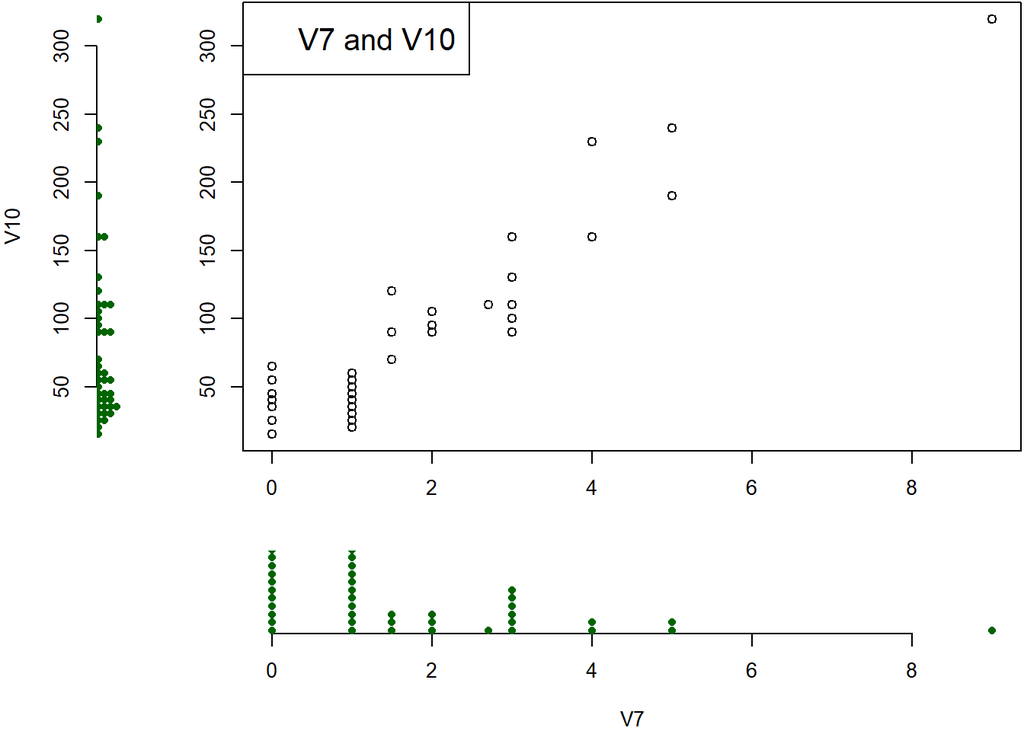

```r
margin_dot_plot(df$V7, df$V10, xlabel = "V7", ylabel = "V10", name = "V7 and V10")
```

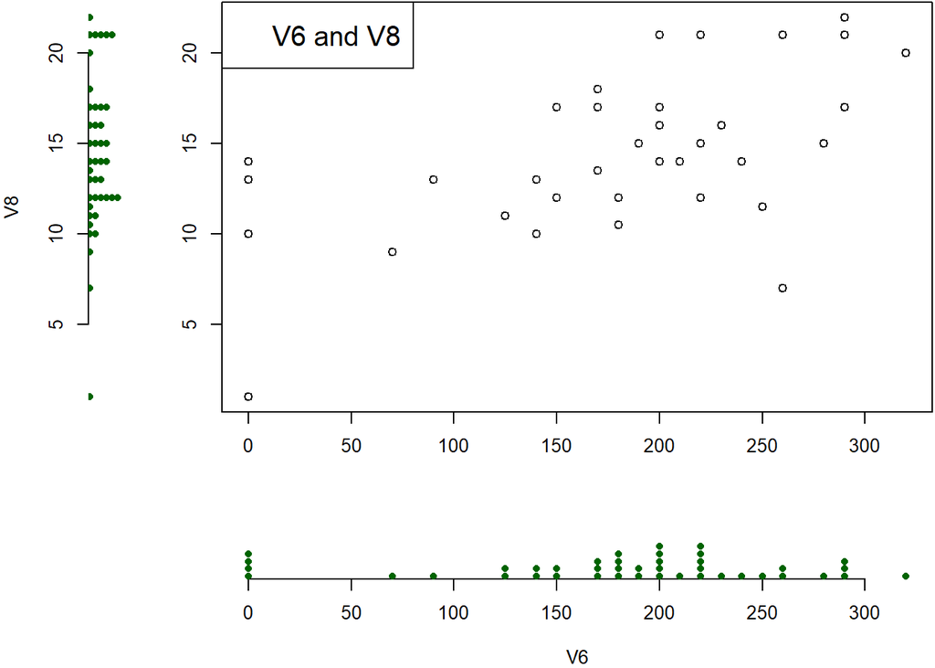

```r
margin_dot_plot(df$V6, df$V8, xlabel = "V6", ylabel = "V8", "V6 and V8")
```

V7 and V10 seems to highly correlated and so does V6 and V8.

## Conclusion

V7 and V10 have a strong correlation, and the same goes for V6 and V8. Moreover V10 and V6 appears to have some large outliers, due to a high variance and low mean, which might need to be removed. Moreover, wether intended or not, V4 and V5 appears to behave more like categorical rather than numerical nature and they have been excluded.

# Step 3: Check for normality

## Each attribute

We start by checking the normality of each attribute:

```r
library(MASS)

get_best_lambda <- function(data_vector, name = "")  {
    # Transform data
    # Make box cox plot on our data
    df_box_cox<- boxcox(data_vector~1,lambda=seq(-2, 2, 1/10))# Can also be seq(-.5, 1.5,.01)

    # Get best lambda
    max_lambda <- df_box_cox$x[which.max(df_box_cox$y)]

    legend("left",
           paste0(name, " Best lambda", "\n",
                  "The best lambda is ", round(max_lambda, 3), "\n"),
           cex = 0.75,
           bty = "n")
    return(max_lambda)
}

box_cox_transformation <- function(data_vector, name = ""){

  lambda <- get_best_lambda(data_vector, name)
  if (lambda == 0){
    transformed_vector <- log(data_vector)
  }

  else {
  transformed_vector <- ( (data_vector^lambda) - 1)/lambda
  }

  return(transformed_vector)
}


test_norm <- function(data_vector, name = " ", signigicance = 0.05) {
  # You can chose the following significance levels
  # 0.01
  # 0.05
  # 0.10

  if (signigicance == 0.01){
    signigicance_col <- 2
  }

  else if (signigicance == 0.05){
    signigicance_col <- 3
  }

  else if (signigicance == 0.1){
    signigicance_col <- 4
  }


  # ----- QQ plot -----
  qq <- qqnorm(data_vector, plot.it = F)

  # ----- Hypothesis test ------
  # Create Testing table
  n <- c(5, 10, 15, 20, 25, 30, 35, 40, 45, 50, 55, 60, 75, 100, 150, 200, 300)
  one <- c(0.8299, 0.8801, 0.9126, 0.9269, 0.9410,
        0.9479, 0.9538, 0.9599, 0.9632, 0.9671,
        0.9695, 0.9720, 0.9771, 0.9822, 0.9879, 0.9905, 0.9935)

  five <- c(0.8788, 0.9198, 0.9389,
        0.9508, 0.9591, 0.9652,
        0.9682, 0.9726, 0.9749,
        0.9768, 0.9787, 0.9801,
        0.9838, 0.9873, 0.9913, 0.9931, 0.9953)

  ten <- c(0.9032, 0.9351, 0.9503,
        0.9604, 0.9665, 0.9715,
        0.9740, 0.9771, 0.9792,
        0.9809, 0.9822, 0.9836,
        0.9866, 0.9895, 0.9928, 0.9942, 0.9960)
  testing_tbl <- data.frame(
  n,
  one,
  five,
  ten
  )

  # Find index of testing (n)
  sample_size <- length(data_vector)
  i <- 1
  prev_value = NaN
  for (n in testing_tbl$n){

    if (sample_size > testing_tbl$n[length(testing_tbl$n)]){
      i <- length(testing_tbl$n)
      break
    }

    if (n == sample_size){
      exact_sample_size <- TRUE
      break
    }

    else if ( n > sample_size & prev_value < sample_size){
      break
    }
    i <- i + 1
    prev_value <- n
  }

  # ----- Normal -------
  cor_coef <- cor(qq$x, qq$y)
  normality = FALSE
  if (cor_coef >= testing_tbl[i, signigicance_col]){
    plot(qq, xlab = "Theoretical quantiles", ylab = "Sample quantiles", main = paste0(name, " QQ plot"))
    qqline(data_vector)
    legend("topleft",
           paste0("Rq: ", round(cor_coef, 3), "\n",
                  "Test rq: ", testing_tbl[i, signigicance_col], "\n",
                  "Alpha: ", signigicance, "\n",
                  "n: ", n, "\n",
                  "NORMAL!"),
           cex = 0.65,
           bty = "n")
    normality = TRUE
    return(normality)
  }

  # ----- Not normal -----
  else {

    plot(qq, xlab = "Theoretical quantiles", ylab = "Sample quantiles", main = paste0(name, " QQ plot"))
    qqline(data_vector)
    legend("topleft",
           paste0("Rq: ", round(cor_coef, 3), "\n",
                  "Test rq: ", testing_tbl[i, signigicance_col], "\n",
                  "Alpha: ", signigicance, "\n",
                  "n: ", n, "\n",
                  "Not NORMAL!"),
           cex = 0.65,
           bty = "n")
  }
}
```

Now apply above function to each attribute

```r
par(mfrow = c(2, 3))
i = 1
for (colname in colnames(df)) {
  test_norm(df[, i], name = colname)
  i = i + 1
}
```

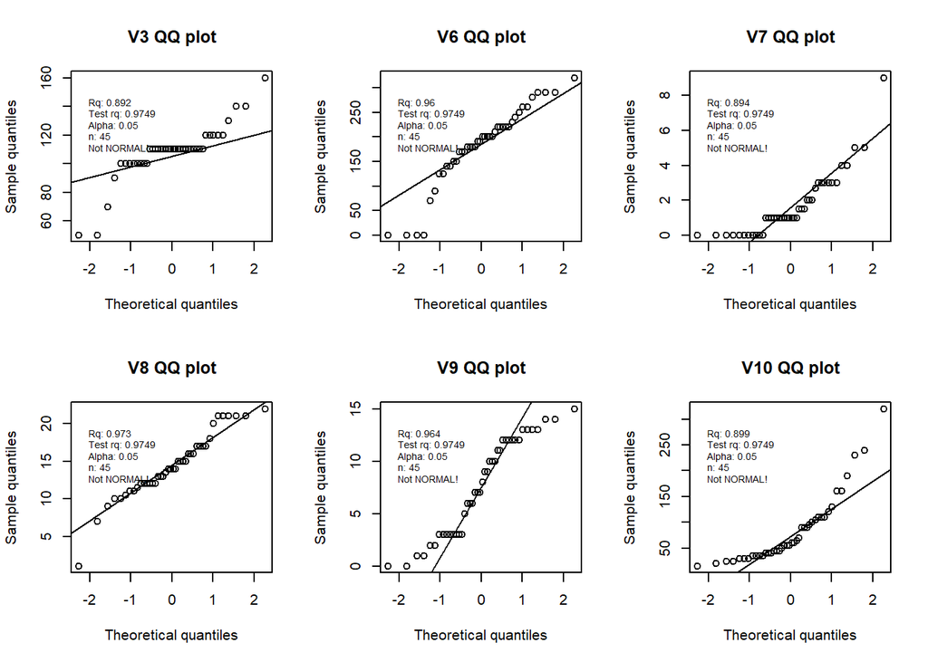

None of the data is normally distributed within alpha = 0.05, let us transform it then:  
Now since the values must be positive, then we need to remove V6, V7, V9:

```r
par(mfrow= c(1, 3))
z_df <- df[, c(1, 4, 6)]
i = 1
for (colname in colnames(z_df)){
  z_df[, i] <- box_cox_transformation(z_df[, i], name = colname)
  i = i + 1
}
```

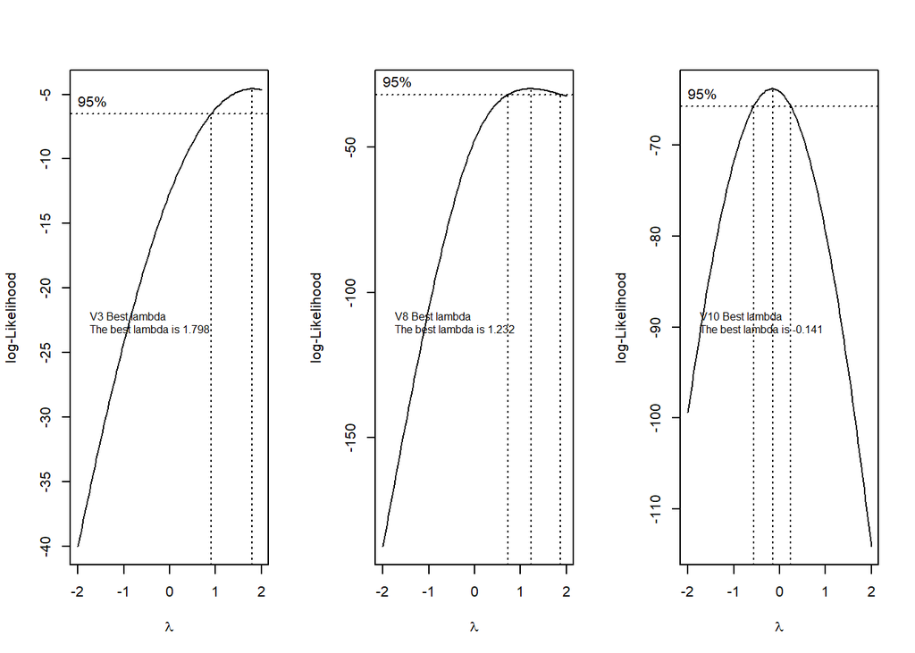

Let us now test for normality:

```r
i = 1
par(mfrow= c(1, 3))
for (colname in colnames(z_df)){
  test_norm(z_df[, i], name = paste0(colname, " (Transformed) "))
  i = i + 1
}
```

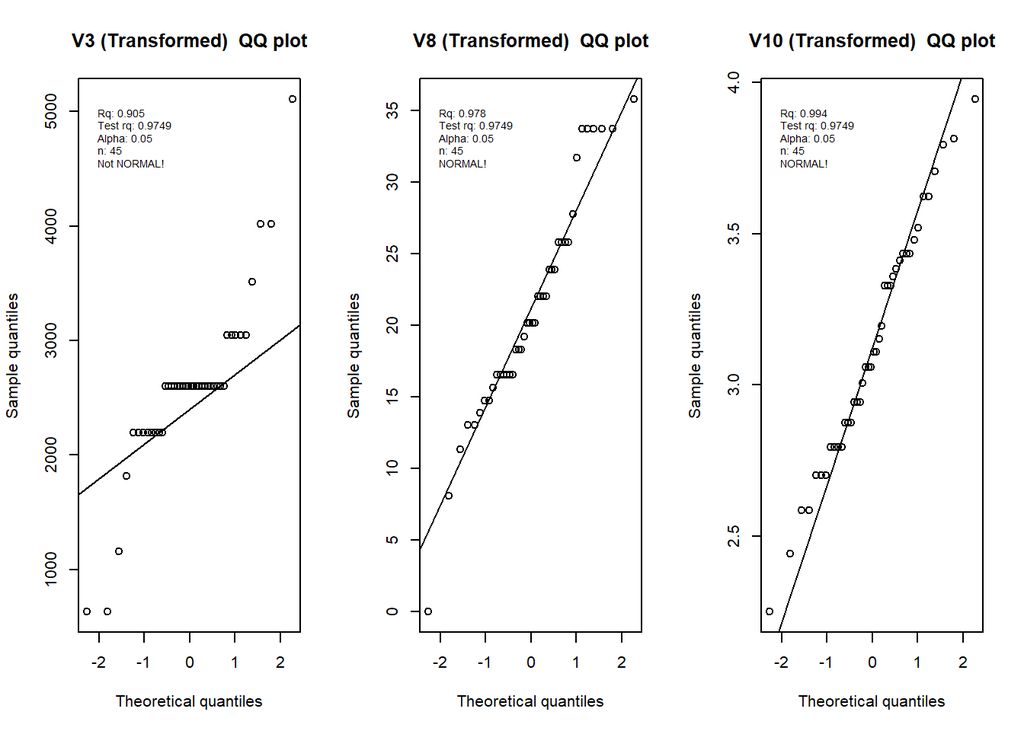

V8 and V10 are normal if we transform them, therefore, we either have to proceed with these two alone or use non normal transformations.  
Howevever, we can also try to exlude the non-positive from V6, V7, V9

```r
z_df <- df

i = 1
for (colname in colnames(df)){
  z_df <- subset(z_df, z_df[,i] > 1)
  i = i + 1
}
z_df
```

```
##     V3  V6  V7   V8 V9 V10
## 1  110 180 1.5 10.5 10  70
## 6  110 250 1.5 11.5 10  90
## 9  100 220 2.0 15.0  6  90
## 10 130 170 1.5 13.5 10 120
## 13 140 190 4.0 15.0 14 230
## 14 100 200 3.0 16.0  3 110
## 16 100 200 3.0 17.0  3 110
## 18  70 260 9.0  7.0  5 320
## 22 110 140 4.0 10.0  7 160
## 27 120 240 5.0 14.0 12 190
## 29 160 150 3.0 17.0 13 160
## 31 140 220 3.0 21.0  7 130
## 32  90 170 3.0 18.0  2  90
## 34 120 210 5.0 14.0 12 240
## 40 100 150 2.0 12.0  6  95
```

Let us then transform:

```r
par(mfrow= c(2, 3))
i = 1
for (colname in colnames(z_df)){
  z_df[, i] <- box_cox_transformation(z_df[, i], name = colname)
  i = i + 1
}
```

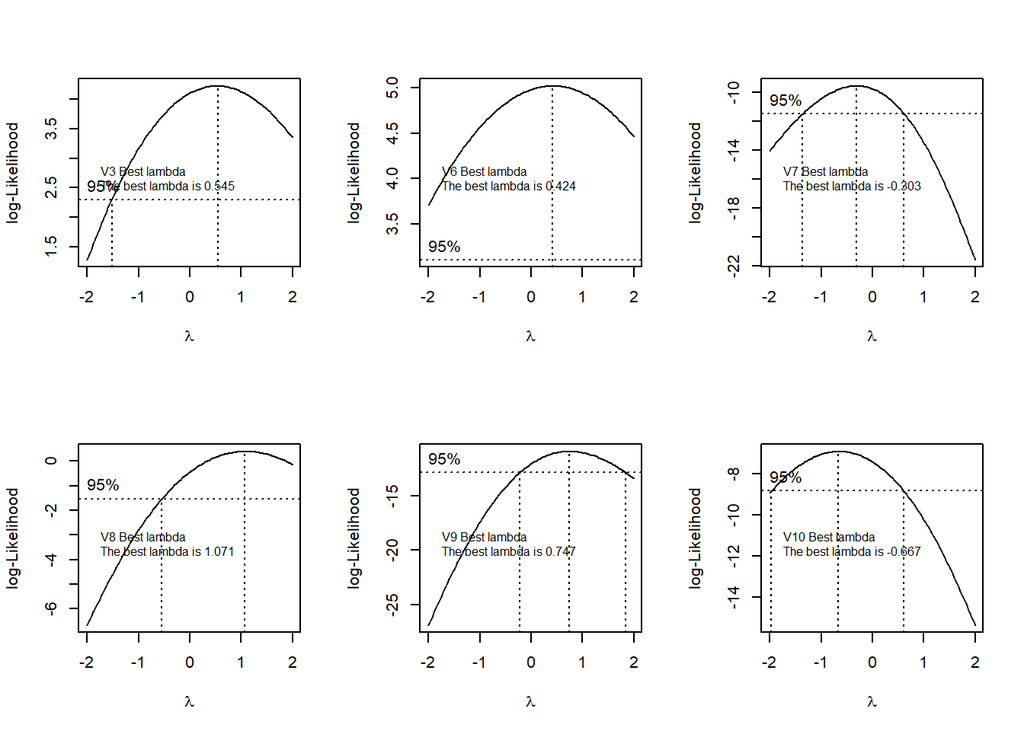

```r
i = 1
par(mfrow= c(2, 3))
for (colname in colnames(z_df)){
  test_norm(z_df[, i], name = paste0(colname, " (Transformed) "))
  i = i + 1
}
```

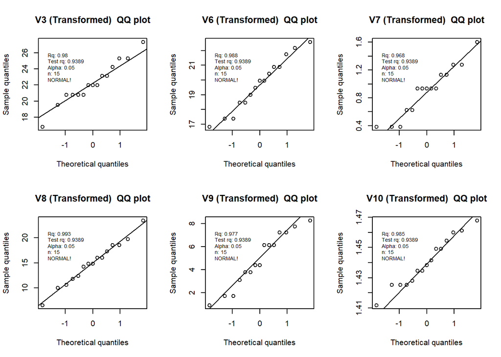

Now they are all normal. So if we want a normal classifer we need to both exclude zero variables from the data set and transform it, other we need a non-normal classifier. Let us continue with the transformed data and see if it is multivariate normal:

## Attribute pairs

We will test bivariate normality for each pair:

```r
FindcrikChi <- function(n=30, p=2, alpha= 0.05, n_simulations=10000){

    cricvec <- rep(0, n_simulations)  #vector for the rQ result collection#

    for(i in 1:n_simulations){
        #iteration to estimate rQ#
        numvec <- rchisq(n, p)  #generate a data set of size n, degree of freedom=p#
        d <- sort(numvec)
        q <- qchisq((1:n-0.5)/n, p)
        cricvec[i] <- cor(d,q)
    }

    scricvec <- sort(cricvec)
    cN <- ceiling(n_simulations* alpha) #to be on the safe side I use ceiling instead of floor(), take the 'worst' alpha*N cor as rQ, everything lower than that is deemed as rejection#
    cricvalue <- scricvec[cN]
    result <- list(cN, cricvalue, scricvec)
    return(result[[2]])
}

multi_var_norm <- function(df, sim_cor, alpha, name, remove_outlier = FALSE, n_outliers = 1) {

  # Data and parameters
  n <- nrow(df) # observations
  p <- ncol(df) # number of variables
  D2 <- mahalanobis(df,
                    center  = colMeans(df),
                    cov = cov(df),
                    tol=1e-20) # generalized squared distance
  # Removes outliers if necessary
  if(remove_outlier == TRUE){

    i = 0
    while (i < n_outliers){
    #This is where we remove outliers. This will most likely change the correlation value and the % number of points in the contour.
    D2 <- D2[-which.max(D2)]
    i = i + 1
    }
  }

  # Chi square qq plot
  chi_plot <- qqplot(qchisq(ppoints(n, a = .5), df = p), D2,
                     plot.it = F) # chi square plot values.
  my_cor <- cor(chi_plot$x, chi_plot$y) # correlation value
  critical_value <- qchisq(p = alpha,
                           df = p,
                           lower.tail = F) # calculate critical value

  # Proportion of points below alpha value
  prop_within_contour <- round(length(D2[D2 <= critical_value]) / length(D2),4) #

  quantiles <- quantile(D2)
  quantile_25 <- quantiles[2]
  quantile_50 <- quantiles[3]
  quantile_75 <- quantiles[4]

  plot(chi_plot, #From here and downwards it is only how you want the plot to look.
       ylab = 'Mahalanobis distances',
       xlab = 'Chi-square quantiles',
       main = paste0(name, ' alpha = ',alpha)) # plot chi square plot

  # Q line
  y <- rchisq(500, df = p)
  qqline(y, distribution = function(n) qchisq(n, df = p), prob = c(0.1, 0.6))

  # Lines for quantiles
  abline(h = quantile_50, lty = 2) # 50% quantiles becayse book p. 187
  abline(h = critical_value, lty = 2, col = "red") # Below Critical value

  if(my_cor > sim_cor){
    conclusion <- "Normally distributed!"
  }

  else {
    conclusion <- "NOT normally distributed!"
  }
  legend("topleft",
         paste0("r = ", round(my_cor,4), "\n",
                "Simulated r Value: ", sim_cor, "\n",
                "% Below critical range: ", prop_within_contour, "\n",
                "Expected if normal: ", 1-alpha, "\n",
                conclusion),
         cex = 0.75,
         bty = "n") # add legend to plot
}


bivar_pairs <- function(data_frame, significance = 0.05, remove_outliers = FALSE, n_outliers = 1, n_simulations = 10000) {

sim_cor <- FindcrikChi(n = length(data_frame[,1]),
                          p = 2,
                          alpha = significance,
                          n_simulations)

prev <- c()
i = 1
for (col_name in colnames(data_frame)){

  j = 1
  for (col_name_inner in colnames(data_frame)){

    if (i == j){
      j = j + 1
      next
    }

    else if (j %in% prev){
      j = j + 1
      next
    }

    else{
      multi_var_norm(df = data_frame[, c(i, j)],
                 sim_cor = sim_cor,
                 alpha = significance,
                 name = paste0(col_name, " & ", col_name_inner, " "),
                 remove_outlier = remove_outliers,
                 n_outliers = n_outliers)

    }
    j = j + 1
  }
  prev <- append(prev, i)
  i = i + 1
  }
}
```

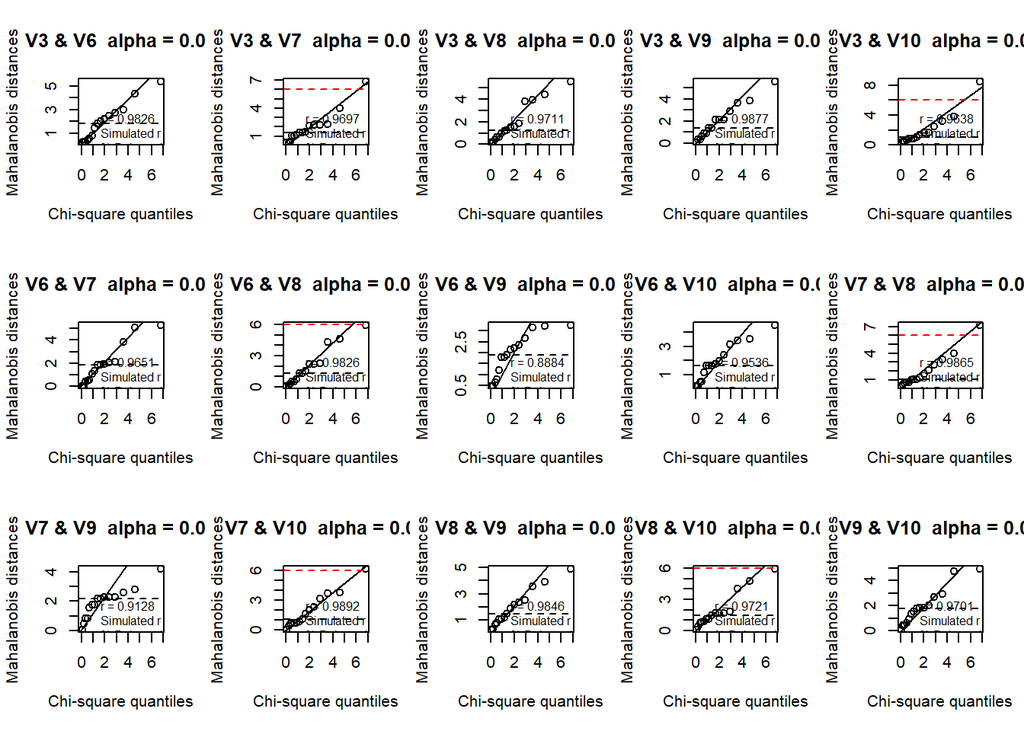

```r
par(mfrow = c(3, 5))
bivar_pairs(z_df)
```

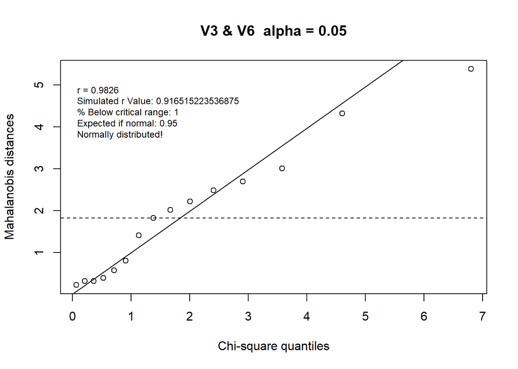

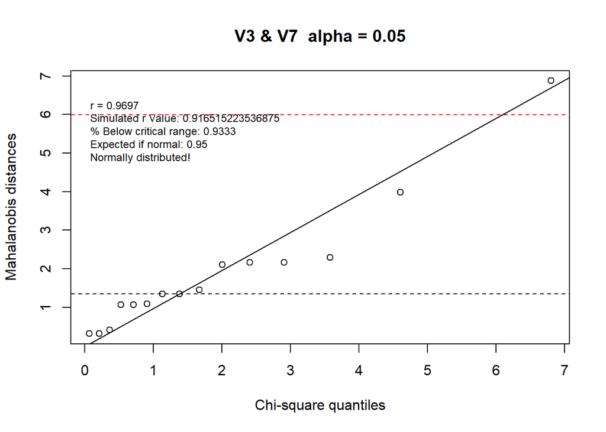

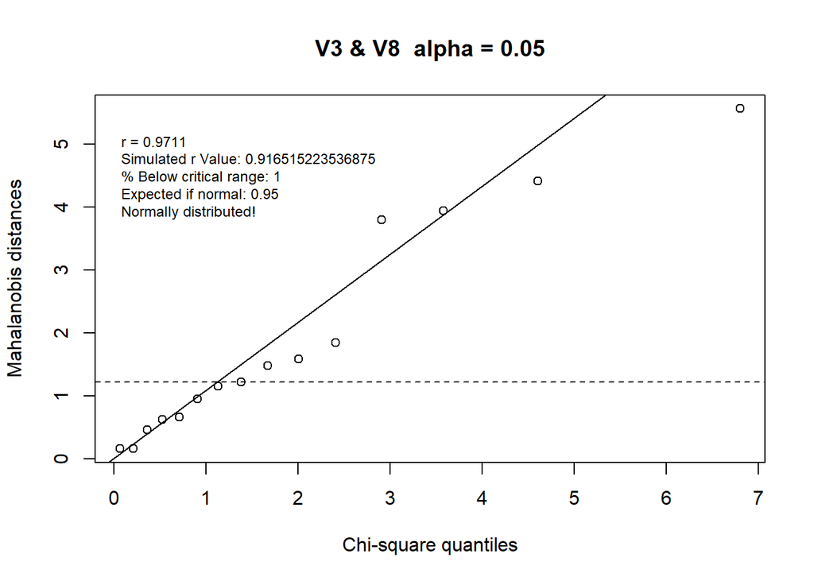

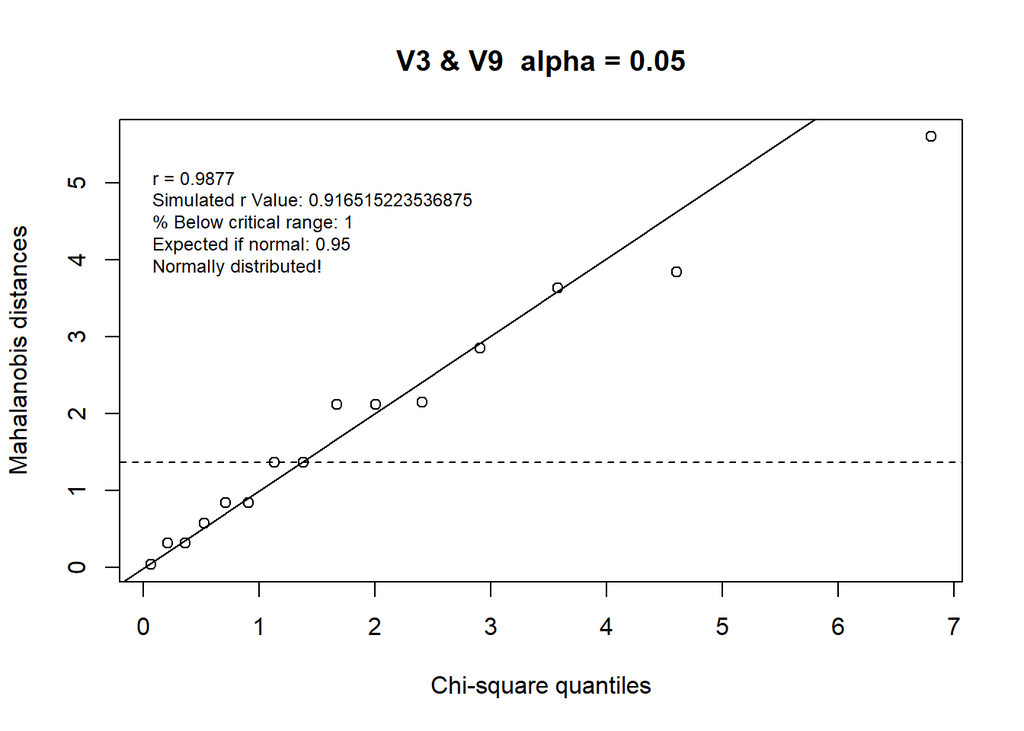

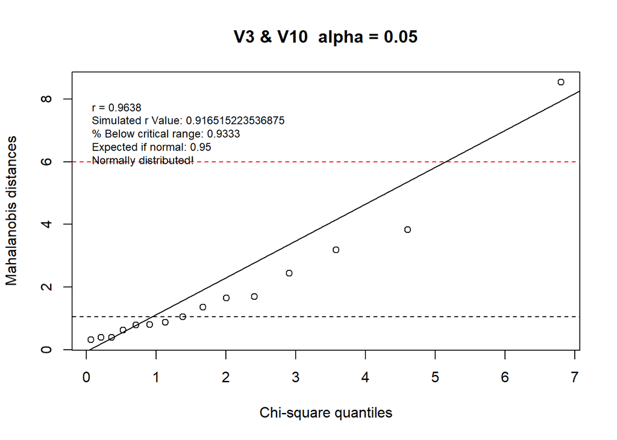

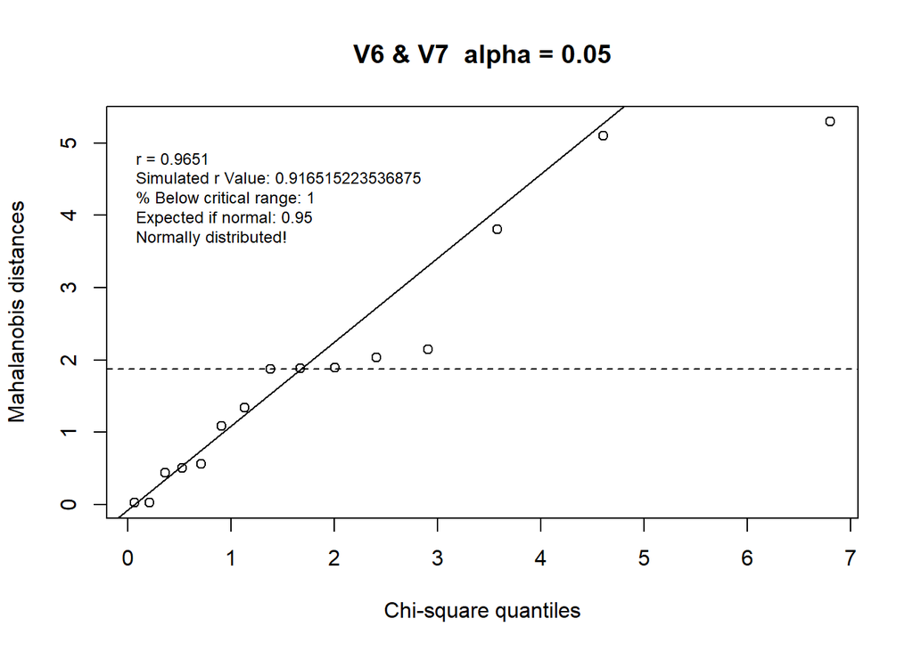

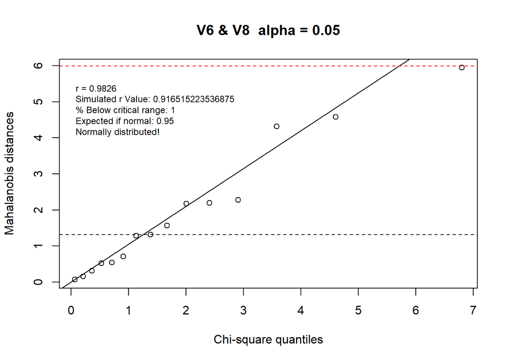

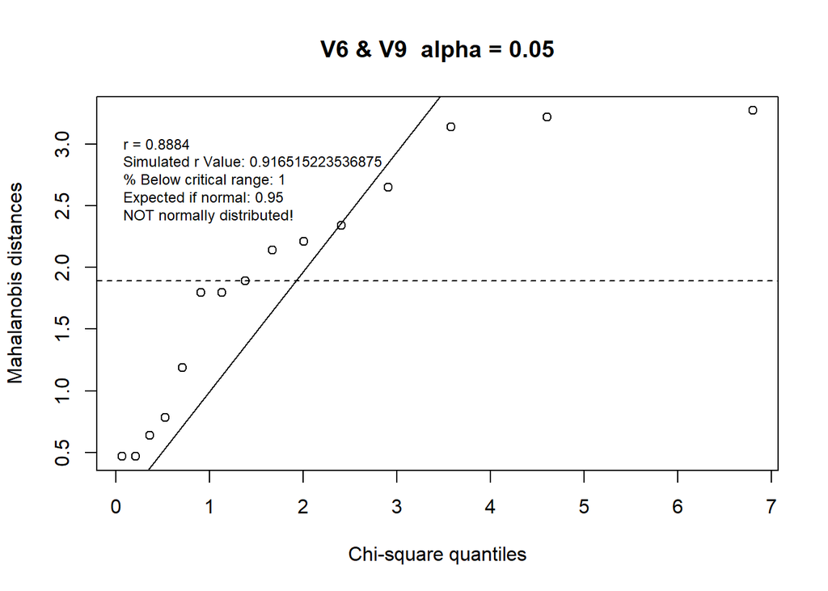

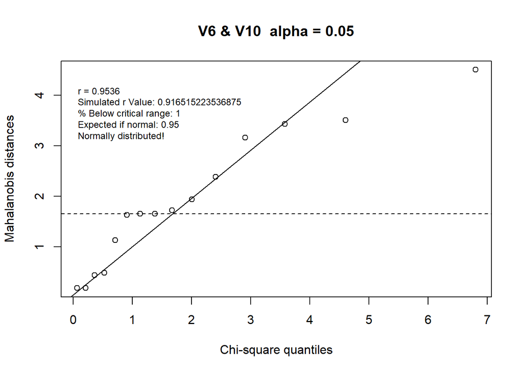

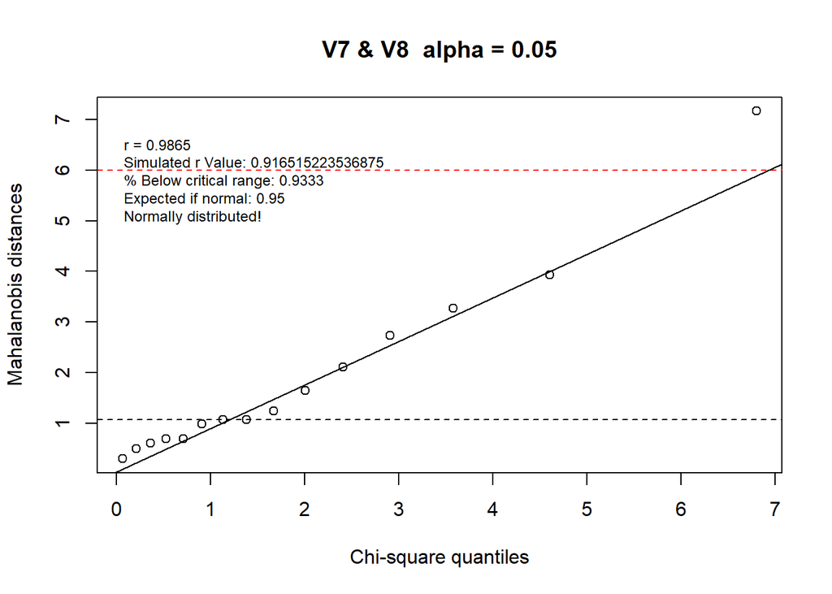

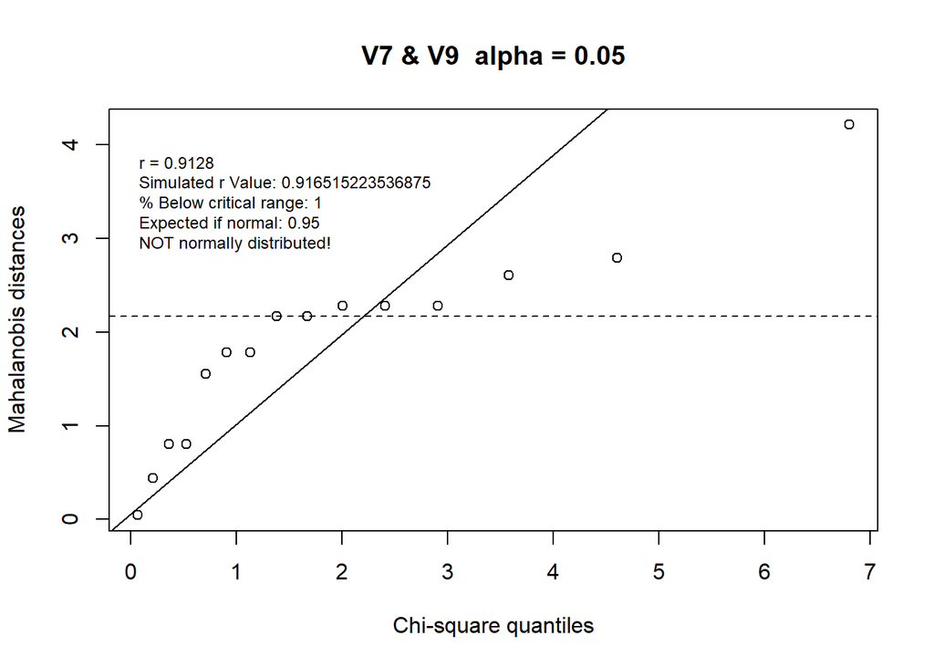

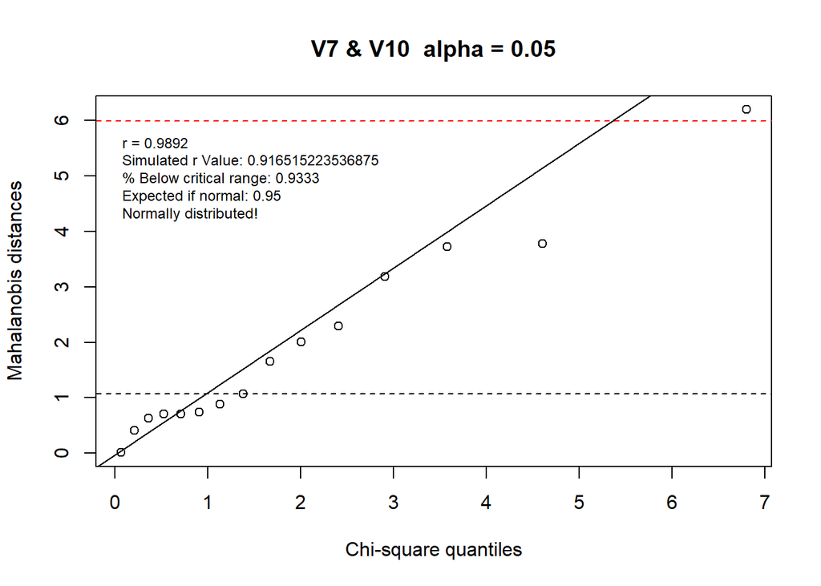

[3 more figures not shown]

```r
bivar_pairs(z_df)
```

The following pairs are not normal:  
- V6 and V9  
- V7 and V9